# Weather Events causing Health and Economic problems in the US

Storms and other severe weather events can cause both public health and economic problems for communities and municipalities. Many severe events can result in fatalities, injuries, and property damage, and preventing such outcomes to the extent possible is a key concern.

This project involves exploring the U.S. National Oceanic and Atmospheric Administration’s (NOAA) storm database. This database tracks characteristics of major storms and weather events in the United States, including when and where they occur, as well as estimates of any fatalities, injuries, and property damage.

## Synopsis

The data analysis performed on the NOAA storm database which contains data between 1950 and 2011 showed that tornadoes was the most harmful weather events to the population health while Floods has the greatest economic consequence.

## Data Processing

The source data was retrived from [Storm Events Database](https://d396qusza40orc.cloudfront.net/repdata%2Fdata%2FStormData.csv.bz2) and was downloaded to local computer then stored in a variable called StormData. Necessary libraries were loaded to be use for this data analysis.

```r
setwd("C:/Users/Dell/Downloads")
sourceURL <- "https://d396qusza40orc.cloudfront.net/repdata%2Fdata%2FStormData.csv.bz2"
download.file(sourceURL,'rawdata_sda.csv.bz2')
stormData <- read.csv("rawdata_sda.csv.bz2", na.strings = "NA")
library(plyr)
library(ggplot2)
library(grid)
```

#### Population Health

Data under INJURIES and FATALITIES columns has been summed up and named under new CASUALTIES column. This is needed to determine the most harmful event type in population health. The top 10 highest count will be selected from the new list.

```r
stormData$CASUALTIES <- stormData$INJURIES +stormData$FATALITIES
casualties <- with(stormData,aggregate(CASUALTIES, by= list(EVTYPE),sum))
casualties <- head(arrange(casualties, desc(x)),10)
casualties <- arrange(casualties,x)
```

#### Economic Problems for Communities and Municipalities

```r
stormData$PROPDMGEXP <- toupper(stormData$PROPDMGEXP)
stormData$CROPDMGEXP <- toupper(stormData$CROPDMGEXP)
stormData$PROPDMGEXP[stormData$PROPDMGEXP %in% c("", "+", "0","-","?")] <- 0
stormData$CROPDMGEXP[stormData$CROPDMGEXP %in% c("", "+", "0","-","?")] <- 0
stormData$PROPDMGEXP[stormData$PROPDMGEXP == "B"] <- 9
stormData$CROPDMGEXP[stormData$CROPDMGEXP == "B"] <- 9
stormData$PROPDMGEXP[stormData$PROPDMGEXP == "M"] <- 6
stormData$CROPDMGEXP[stormData$CROPDMGEXP == "M"] <- 6
stormData$PROPDMGEXP[stormData$PROPDMGEXP == "K"] <- 3
stormData$CROPDMGEXP[stormData$CROPDMGEXP == "K"] <- 3
stormData$PROPDMGEXP[stormData$PROPDMGEXP == "H"] <- 2
stormData$CROPDMGEXP[stormData$CROPDMGEXP == "H"] <- 2

stormData$PROPDMGEXP <- 10^(as.numeric(stormData$PROPDMGEXP))
stormData$CROPDMGEXP <- 10^(as.numeric(stormData$CROPDMGEXP))
stormData$DAMAGES <- stormData$PROPDMG * stormData$PROPDMGEXP + stormData$CROPDMG * stormData$CROPDMGEXP
stormData$PDAMAGES <- stormData$PROPDMG * stormData$PROPDMGEXP
stormData$CDAMAGES <- stormData$CROPDMG * stormData$CROPDMGEXP

pdamages <- with(stormData,aggregate(PDAMAGES/10^7, by= list(EVTYPE),sum))
pdamages <- head(arrange(pdamages, desc(x)),10)
pdamages <- arrange(pdamages,x)
cdamages <- with(stormData,aggregate(CDAMAGES/10^7, by= list(EVTYPE),sum))
cdamages <- head(arrange(cdamages, desc(x)),10)
cdamages <- arrange(cdamages,x)
damages <- with(stormData,aggregate(DAMAGES/10^7, by= list(EVTYPE),sum))
damages <- head(arrange(damages, desc(x)),10)
damages <- arrange(damages,x)
```

## Result

From the plots below, tornado has the highest value in terms of the number of affected casualties under population health (Figure 1) while flood has the highest value in terms of the greatest economic consequences (Figure 2). Furthermore, property damage is mostly affected by flood while crop damage is impacted mostly by drought (Figure 3).

#### Population Health

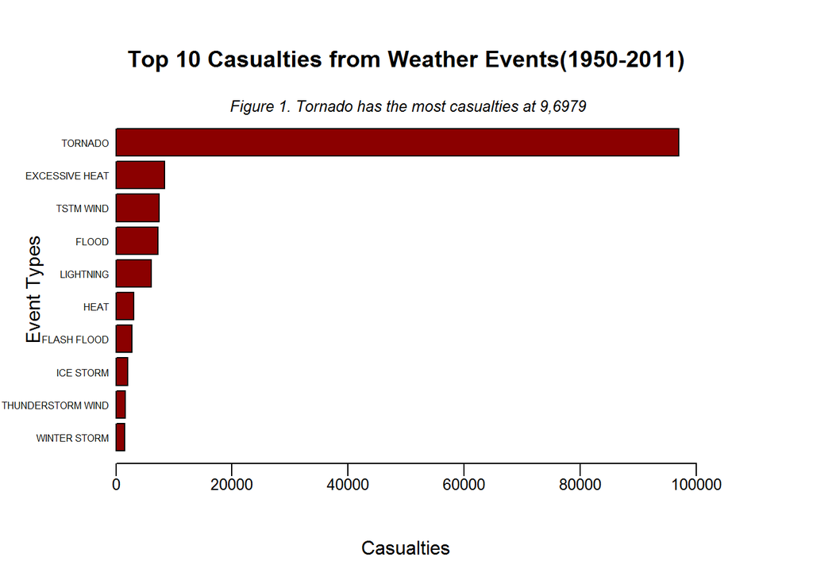

```r
colnames(casualties) <- c("Type", "Count")
options(scipen = 1)
par(mar= c(5,5,5,5), mgp = c(3.1,0.3,0))
barplot(casualties$Count,
        names.arg = casualties$Type,
        xlab = "Casualties",
        ylab = "Event Types",
        horiz = TRUE,
        cex.names = 0.5,
        cex.axis = 0.8, legend.text = TRUE,
        las = 1,
        col = "darkred",
        main = "Top 10 Casualties from Weather Events(1950-2011)",
        xlim = c(0,100000))
mtext(" Figure 1. Tornado has the most casualties at 9,6979",
      side=3,
      outer=T,
      adj=0.5,
      line=-5,
      font = 3,
      cex = 0.8)
```

#### Economic Problems for Communities and Municipalities

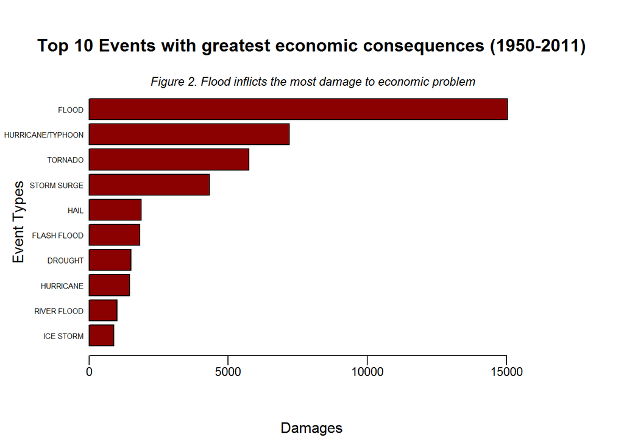

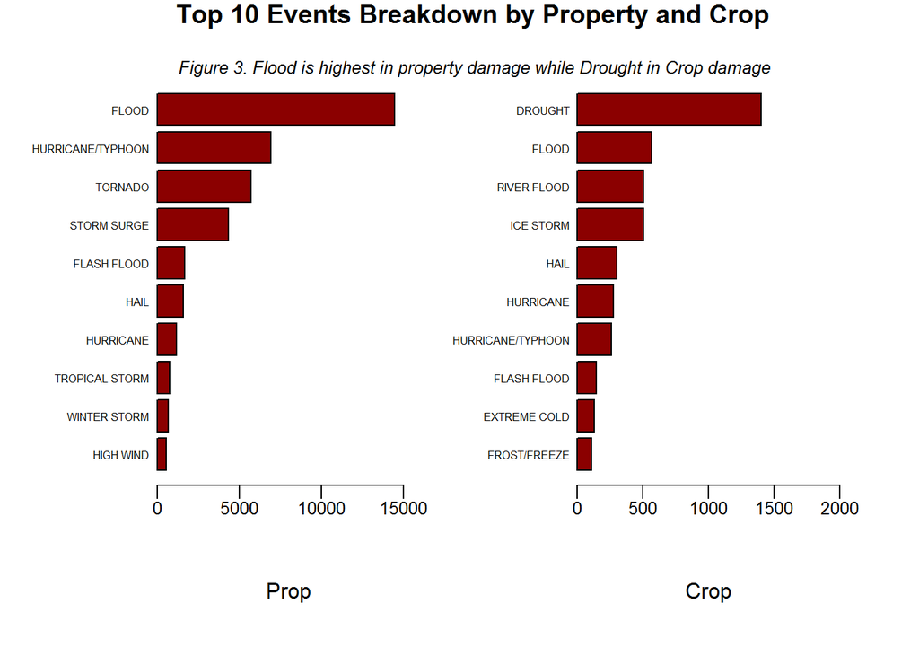

```r
colnames(damages) <- c("Type", "Count")
par(mar= c(5,5,5,5), mgp = c(3.5,0.3,0))
barplot(damages$Count,
        names.arg = damages$Type,
        xlab = "Damages",
        ylab = "Event Types",
        horiz = TRUE,
        cex.names = 0.5,
        cex.axis = 0.8,
        las = 1,
        col = "darkred",
        main = "Top 10 Events with greatest economic consequences (1950-2011)",
        xlim = c(0,16000))
mtext(" Figure 2. Flood inflicts the most damage to economic problem",
      side=3,
      outer=T,
      adj=0.5,
      line=-5,
      font = 3,
      cex = 0.8)

colnames(pdamages) <- c("Type", "Count")
par(mfrow = c(1, 2), mar = c(5, 4, 2, 2), oma = c(1.5, 2, 1, 1))
barplot(pdamages$Count,
        names.arg = pdamages$Type,
        xlab = "Prop",
        horiz = TRUE,
        cex.names = 0.5,
        cex.axis = 0.8,
        las = 1,
        col = "darkred",
        xlim = c(0,16000))
colnames(cdamages) <- c("Type", "Count")
barplot(cdamages$Count,
        names.arg = cdamages$Type,
        xlab = "Crop",
        horiz = TRUE,
        cex.names = 0.5,
        cex.axis = 0.8,
        las = 1,
        col = "darkred",
        xlim = c(0,2000))
mtext(" Figure 3. Flood highest in property damage while Drought in Crop damage",
      side=3,
      outer=T,
      adj=0.5,
      line=-2,
      font = 3,
      cex = 0.8)
title(main = "Top 10 Events Breakdown by Property and Crop", outer = TRUE)
```